# Predictive Capability of Text Mining in Yelp Reviews

Analyzing the text mining techniques and several machine learning algorithms in predict business and reviews attributes

Giuliano Sposito

November, 2015

This is the report for the Capstone Project of the Coursera Data Science Specialization by Johns Hopkins Bloomberg School of Public Health.

## Introduction

In this study we will study the ability of the texts, in the Yelp’s Reviews dataset [(Yelp Challenge, 2015)](http://www.yelp.com/dataset_challenge), to be used to predict things business characteristics and attributes. For example, is it possible, through them, to predict the evaluation stars, if the establishment has free Wi-Fi, or have parking? There in the text comments, information about the price, if it is good for kids or groups? Comments about how noisy the environment is?

In addition, we will try to understand what would be the best approach for text prediction and what are the limitations of this technique in the Yelp’s context? Has a model, trying to predict this business attributes enough accuracy to be considered useful?

## Methods

### General Text Mining Approach

The classic textbook approach to Texting Mining is to create a *Corpus* of text to be preprocessed. In the pre process the text if *normalized* and *cleaned* transforming all words to lowercase, removing punctuation, extra whitespaces and even numbers, removing non-significant words, as *a, and, also, the, etc.* (it’s known as *stop words*). In some case, the common word endings (e.g., “ing”, “es”, “s”) are removed also. This is referred to as “stemming” documents. We stem the documents so that a word will be recognizable to the computer, despite whether or not it may have a variety of possible endings in the original text.

After this process is created a Term Document Matrix, or TDM [(Feinerer, 2005)](https://cran.r-project.org/web/packages/tm/vignettes/tm.pdf), that is a sparse matrix that counts the occurrence of all unique words found in text corpus for each document in corpus. Therefore, the TDM characterizes each document, so it can be used as features to be analyzed or as input in machine learning algorithms trying to predict aspects to the object associated to the text or the text itself.

A great description of the process above, using R, can be seen in this [online tutorial](https://rstudio-pubs-static.s3.amazonaws.com/31867_8236987cf0a8444e962ccd2aec46d9c3.html).

### Business Attributes Predictive Analysis Workflow

The method to study the predictive capability of a text from Yelp `Review` tells us things about an `Business` attributes: (1) for each `Business` attribute of interrest, try to fit a model using the TDM of a subset from text in `Reviews` for that Business. After that, (2) use this model to try to predict the attribute from other text Review subset. So basically what we did was to test several machine learning algorithms accuracy in use the TDM of text `Reviews` to predic several `Business` attribute.

A diagram showind the first step (1) can be seen in the image below, the `Business` Yelp dataset is preprocessed to transform and prepare the attributes to be used in the fitting process (transform them in factors, converting the `NA` values in an `unknown` value, merging some scales to reduce the dimensionality, etc.). After this, the `Business` dataset is merged with the `Review` dataset, so for each text `Review` now has the attributes values to which the text refers. This `Business-Review` dataset is separated in **Training** and **Test** datasets using [Caret](https://cran.r-project.org/web/packages/caret/index.html) CreateDataPartition function. The **Training** dataset’s text is processed using the [RTextTools](https://cran.r-project.org/web/packages/RTextTools/index.html) package to extract the TDM, and to fit a model to a specific `Business` attribute.

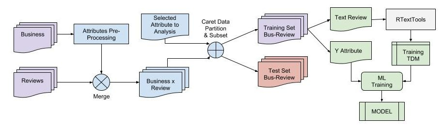

In the second step (2) the accuracy of the model generated is verified using the `Business-Review` Test dataset. This is done creating another *TDM* for the text, but containing the same words present in the *Training TDM*. This is necessary because the model was trained in the *training glossary* so the *Test TDM* must have the same words. The *RTextTool’s create_matrix* function can take another TDM as input to keep the glossary the same. After that, the model fitted in the first step is used to predict the attribute value, and the output is confronted with the real value. The accuracy (and others performance value) is measured using the *Caret’s confusionMatrix* function.

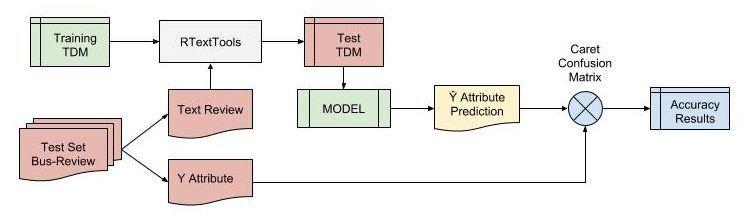

### Source Code

As said, for the analysis we use the [RTextTools](https://cran.r-project.org/web/packages/RTextTools/index.html) package that provides text-mining infrastructure for machine learning analysis, also used the [Caret](https://cran.r-project.org/web/packages/caret/index.html) package to sample and split the dataset and analyses the accuracy. For KNN and Naive Bayes algorithms, we use the [e1071](https://cran.r-project.org/web/packages/e1071/index.html) package.

```r
# example how RTextTools create the TDM, Learning Containers and Predict Results
trainMatrix <- create_matrix(train$text)
predMatrix <- create_matrix(test$text,originalMatrix=trainMatrix)

# RTextTools ML containers
traincontainer <- create_container(trainMatrix, train$y,
                            trainSize=1:train_sample_size, virgin=F)
predContainer <- create_container(predMatrix, test$y,
                            testSize=1:test_sample_size, virgin=F)

# Train Model
mod <- train_model(container=trainCont, algorithm="SVM", ]
                    kernel="linear", cost=1)

# Predict
y_hat <- classify_model(predCont,mod)[[1]]
```

You can see all the code and analysis at [github](https://github.com/GiulSposito/DSS-Capstone), the repository tells the code structure and organization, also the basic instruction to run de code.

### Algorithms and Business Attributes

For time and resources limitations (mainly process power and memory size), for this study we choose analyze the performance of the following machine learning algorithms: [Support Vector Machine (SVM)](https://en.wikipedia.org/wiki/Support_vector_machine), [Maximum Entropy Classifier (MAXENT)](https://en.wikipedia.org/wiki/Multinomial_logistic_regression), [Decision Tree Learning (TREE)](https://en.wikipedia.org/wiki/Decision_tree_learning), [Random Forest](https://en.wikipedia.org/wiki/Random_forest), [K-nearest neighbors (KNN)](https://en.wikipedia.org/wiki/K-nearest_neighbors_algorithm) and [Naive Bayes Classifier (NAIVEBAYES)](https://en.wikipedia.org/wiki/Naive_Bayes_classifier). Aurangzeb Khan [(Khan, A. 2010)](http://www.jait.us/uploadfile/2014/1223/20141223050800532.pdf) write an excellent article about these algorithms in the context of text classifying.

The `Business` attributes selected for the study can be seen in the table below. They was first preprocessed to transform its values in factors and be ready to be used as categories in the ML Classifiers. The `NA values` was reclassified as `unknown` to be processed. Also we do some exercises reducing the number of class of some attributes, for example, the for the `star review` we also create an `emotional attribute` reclassifying the reviews with 1 and 2 stars in “negative”, and the reviews with 4 and 5 stars in “positive” (and removing reviews from 3 stars). Details of each attribute transformation can be seen at source code. This was made because text classifiers notoriously works better with fewer classes and with extreme values.

| Attributes | Classification Values | Number of Classes |
| --- | --- | --- |
| hasWifi | no \| yes | 2 |
| hasWifi | no \| unknown \| yes | 3 |
| hasParking | no \| yes | 2 |
| hasParking | no \| unknown \| yes | 3 |
| noiseLevel | average \| loud \| quiet \| very_loud | 4 |
| noiseLevel | average \| loud \| quiet \| unknown \| very_loud | 5 |
| noisy | no \| yes | 2 |
| noisy | no \| unknown \| yes | 3 |
| priceRange | 1 \| 2 \| 3 \| 4 | 4 |
| priceRange | 1 \| 2 \| 3 \| 4 \| unknown | 5 |
| pricy | no \| yes | 2 |
| pricy | no \| unknown \| yes | 3 |
| goodForKids | no \| yes | 2 |
| goodForKids | no \| unknown \| yes | 3 |
| goodForGroups | no \| yes | 2 |
| goodForGroups | no \| unknown \| yes | 3 |
| hasTV | no \| yes | 2 |
| hasTV | no \| unknown \| yes | 3 |
| smoking | no \| outdoor \| unknown \| yes | 4 |
| goodForSmoking | no \| yes | 2 |
| goodForSmoking | no \| unknown \| yes | 3 |
| reviewEmotion | negative \| positive | 2 |
| reviewEmotion | negative \| positive \| unknown | 3 |
| reviewStars | 1 \| 2 \| 3 \| 4 \| 5 | 5 |

## Results

### Analysis Dataset

After pre-processing the `Business` dataset, se select the ten most frequent business category present in the data, we keep the following:

```
##               Active Life                Automotive
##                      2061                      2692
##             Beauty & Spas Event Planning & Services
##                      3805                      1826
##                      Food          Health & Medical
##                      5105                      2650
##             Home Services                 Nightlife
##                      2527                       513
##               Restaurants                  Shopping
##                     17903                      4633
```

After the merging we stand with 1.1 million `Business-Review` register, to keep the loading time and memory allocated size under control we sampled 500 thousand of Business-Review registers to be used in the analysis.

### Algorithms Analysis

To check the performance (accuracy and time-consuming resources), we confront the chosen algorithms in a simplified classification test. The task is to classify if a `Review` (*reviewEmotion* attribute) are `positive` or `negative` from `Restaurants` category only, here are the Accuracy Results by the number of terms in the Term Document Matrix.

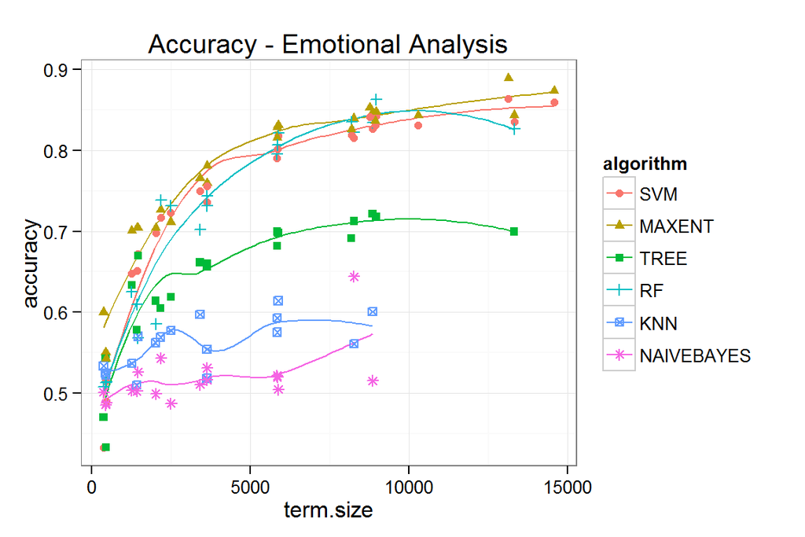

We can see that, for this kind of problem, the SVM, MAXENT and RF algorithms has the best accuracy with values around 85% after 10000 terms in TDM. We also can note that the accuracy stabilizes next 15000 terms. We analyzes the total time to train and predict each test, see below.

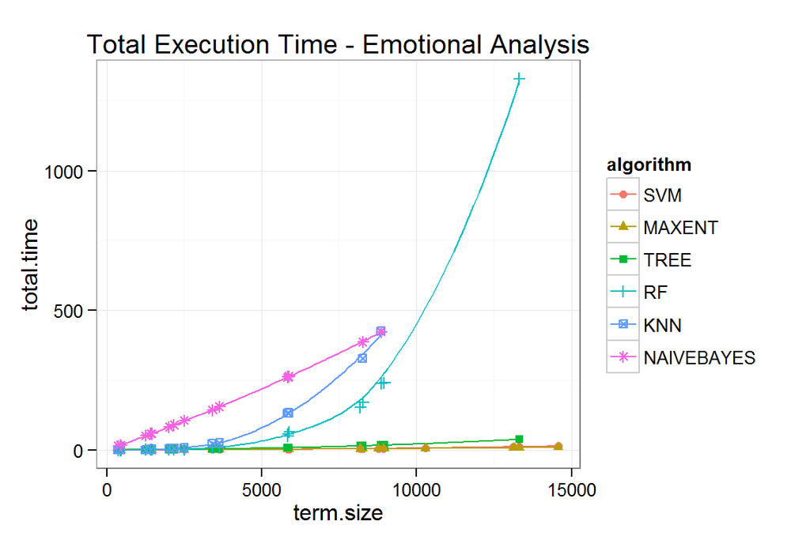

The **TREE**, **SVM** and **MAXENT** algorithms have less time consuming, so taking accuracy and performance as selection criteria, we choose perform the predictive analysis of remaining attributes using only **SVM** and **MAXENT** algorithms.

### Predictive Capability of Business Attributes

For each of the attribute select to the study, and for each of the algorithms we perform the accuracy study, first removing the `unknown` values and after with the `unknown` values. Beside this, each study was applying once to the *Restaurant* category only and after to *All* categories in the study dataset (We hypothesized that the `Review` text glossary for one category is different for other category).

Also, for each attributed analyzed, we eliminate the prevalence effect in the samples, i.e., we balance to equal numbers of the classes to a specific attribute. For example, the `smoking` attribute in the `Business_Review` dataset has around 95000 samples with value `NO`, 117000 samples with `Unknown` and 287000 with `Yes` value, so to avoid the fitted model guess more `Yes` and be more right then wrong, we balance the training and test samples to have equals numbers (95000, the lowest number) of `No`, `Unknown` and `Yes` values.

After applying the Accuracy test, several times, trying to predict the attributes using SVM and MAXENT algorithms to a Term Document Matrix with more than 15000 terms, of balanced `Business-Review` samples, and take an average, we show bellow the results of the prediction that achieve **more than 60% of accuracy**, ordered decreasingly by the MAXENT accuracy.

|  | Attribute | Classes | Business Category | SVM | MAXENT |
| --- | --- | --- | --- | --- | --- |
| 1 | reviewEmotion | 2 | all | 0.8735 | 0.8808 |
| 2 | reviewEmotion | 2 | Restaurants | 0.8697 | 0.8788 |
| 3 | goodForSmoking | 2 | all | 0.7797 | 0.7890 |
| 4 | pricy | 2 | Restaurants | 0.7805 | 0.7860 |
| 5 | pricy | 2 | all | 0.7437 | 0.7527 |
| 6 | goodForSmoking | 2 | Restaurants | 0.7330 | 0.7406 |
| 7 | goodForKids | 2 | Restaurants | 0.7252 | 0.7330 |
| 8 | goodForKids | 2 | all | 0.7180 | 0.7205 |
| 9 | pricy | 3 | all | 0.7117 | 0.7163 |
| 10 | smoking | 3 | all | 0.6937 | 0.7037 |
| 11 | noisy | 2 | all | 0.6790 | 0.6820 |
| 12 | goodForKids | 3 | all | 0.6797 | 0.6810 |
| 13 | noisy | 3 | all | 0.6380 | 0.6500 |
| 14 | goodForGroups | 3 | all | 0.6340 | 0.6407 |
| 15 | reviewEmotion | 3 | Restaurants | 0.6380 | 0.6333 |
| 16 | reviewEmotion | 3 | all | 0.6377 | 0.6290 |
| 17 | goodForGroups | 2 | Restaurants | 0.6222 | 0.6247 |
| 18 | goodForSmoking | 3 | all | 0.6160 | 0.6222 |
| 19 | goodForGroups | 2 | all | 0.6113 | 0.6183 |
| 20 | hasParking | 2 | Restaurants | 0.6015 | 0.6165 |
| 21 | pricy | 3 | Restaurants | 0.6150 | 0.6073 |
| 22 | noisy | 2 | Restaurants | 0.6040 | 0.6040 |
| 23 | hasParking | 2 | all | 0.5905 | 0.6015 |

## Discussion

### Further analysis

Some extra analysis can be applied to this study:

1. With more time and computational power others algorithms could be test. Would be interesting see the performance of Neural Networks (GLMNET and NNET), Gradient Boosting Machine, Bootstrap Aggregating and Latent Dirichlet Allocation (LDA/SLDA)?
2. There are information about Emotion, Smoking, Price Range and *suitable* for kids in the text reviews, this study didn’t try makes a predicting algorithm for this features, but the existence of the signal appears to indicate that is possible combine text and other characteristics to predict this business attributes.
3. We eliminate the prevalence effect because we are interested only in the Text Predictive Capability, but adding this information back, it’s possible make an analysis of Machine Learning classifiers using True Table (True Positives, False Positives, etc.) values and AUC (Area Under the Curve), to define if a business attribute can be, indeed, predict by Yelp `Review` information.

## References

- **Yelp Challenge, 2015**: http://www.yelp.com/dataset_challenge
- **Feinerer, 2005**: Feinerer, I. 2005 - Introduction to the tm Package Text Mining in R - CRAN, July 3, 2015
- **RTextTools**: Automatic Text Classification via Supervised Learning - https://cran.r-project.org/web/packages/RTextTools/index.html - CRAN
- **Caret**: Classification and Regression Training - https://cran.r-project.org/web/packages/caret/index.html - CRAN
- **e1071**: Misc Functions of the Department of Statistics, Probability Theory Group (Formerly: E1071), TU Wien - https://cran.r-project.org/web/packages/e1071/index.html - CRAN
- **GitHub**: Data Science Specialization Capstone Project Source Code repository: https://github.com/GiulSposito/DSS-Capstone
- **Khan, A. 2010**: Khan, A., Baharudin, B., Lee, L., A Review of Machine Learning Algorithms for Text-Documents Classification - JOURNAL OF ADVANCES IN INFORMATION TECHNOLOGY, VOL. 1, NO. 1, FEBRUARY 2010